# Moving Beyond Linearity

Tugas Kuliah STA581 Sains Data

Nur Andi Setiabudi[^1]

2021-10-29

# Pendahuluan

## Tujuan

- Melakukan *cross validation* untuk menghasilkan pemodelan antara tingkat efisiensi penggunaan bahan bakar (direpresentasikan oleh`mpg` atau *miles per gallon*) *versus* daya mesin (dalam `horsepower`) optimal berdasarkan data `ISLR::Auto` dengan metode:
  - *Polynomial regression*
  - *Piecewise constant*
  - *Natural cubic splines*
- Pemodelan dilakukan untuk masing-masing subset berdasarkan negara asal (`origin`), yaitu 1) Amerika, 2) Eropa, dan 3) Jepang

## Output

Mendapatkan model non-linier yang optimal untuk masing-masing negara asal.

# Metodologi

## Tahapan

Pemodelan dilakukan dengan tahapan sebagai berikut:

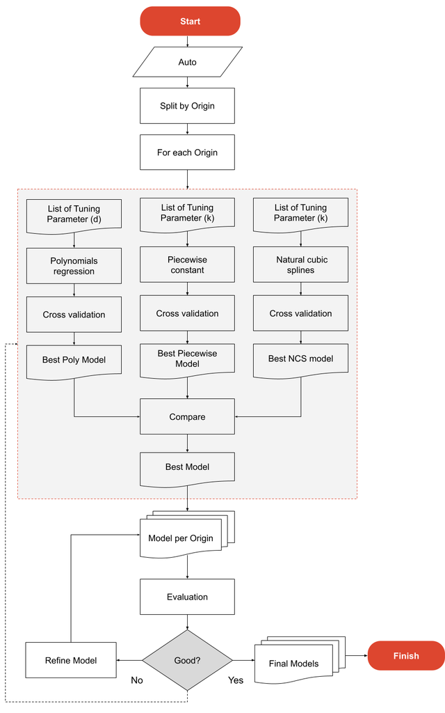

## Skenario *Tuning Parameter*

- *Cross validation*

  *4-fold cross validation* dengan meminimumkan RMSE (*root mean squared error*)
- *Polynomial regression*

  Derajat/*degree* polinomial awal: `c(2:10)`
- *Piecewise constant*

  Jumlah *bins*/*breaks* awal: `c(2:10)`
- *Natural Cubic Spline*

  Jumlah dan lokasi *knots* awal ditentukan perdasarkan *quantile*:

| Jumlah *knots* | Lokasi *knots* (*quantiles*) |
| --- | --- |
| 1 | `.5,` |
| 2 | `.33 * c(1:2)` |
| 3 | `.25 * c(1:3)` |
| 3* | `c(.10, .5, .90)` |
| 4 | `.20 * c(1:4)` |
| 4* | `c(.05, .35, .65, .95)` |
| 5 | `.167 * c(1:5)` |
| 5* | `c(.05, .275, .5, .725, .95)` |
| 6 | `.143 * c(1:6)` |
| 6* | `c(.05, .23, .41, .59, .77, .95)` |
| 7 | `.125 * c(1:7)` |
| 7* | `c(.025, .1833, .3417, .5, .6583, .8167, .975)` |

Sumber : Frank E. Harrell, Jr. (2015). *Regression Modeling Strategies*

## *Tools*

- R
- `splines` dan `stats` untuk pemodelan
- `caret` untuk *cross validation*
- `ggplot2` dan `cowplot` untuk grafik/visualisasi

## Kumpulan Fungsi

Untuk memudahkan iterasi, dibuat beberapa fungsi:

### *Modeling* dan *Cross Validation*

```r
library(splines)
library(caret)

beyondLinear <- function(model, param, df){

  dat <- df

  #' model <string> : modeling approach, ie. polynomial (polynomial regression),
  #'   piecewise (piecewise constant), ncubicspline (natural cubic spline)
  #' param <list or vector> : list of tuning parameters to be evaluated

  cvResult <- mapply(
      function(param, model){

        if (model == "polynomial"){
          f <- bquote(mpg ~ poly(horsepower, degree = .(param)))
        } else if (model == "piecewise") {
          f <- bquote(mpg ~ cut(horsepower, breaks = .(param)))
        } else if (model == "ncubicspline") {
          f <- bquote(mpg ~ ns(horsepower, knots = .(param)))
        }

        trCtl <- trainControl(method='cv', number = 4)
        models <- train(as.formula(f), data = df, trControl = trCtl, method = 'glm')

        RMSE <- models$results$RMSE
        fModel <- models$finalModel

        return(list(models, RMSE, fModel))
      },  model = model, param = param, USE.NAMES = FALSE, SIMPLIFY = FALSE )


  if(!is.null(names(param))){
    paramIdx <- names(param)
  } else {
    paramIdx <- param
  }

  cvScore <- data.frame(paramIdx = as.character(unlist(paramIdx)),
                        score = unlist(sapply(cvResult, "[", 2, USE.NAMES = F)))
  cvScore$param <- param

  bestPos <- which.min(cvScore$score)[1]
  bestParam <- param[[bestPos]]
  bestScore <- cvResult[[bestPos]][[2]]
  bestModel <- cvResult[[bestPos]][[1]]

  predValue <- data.frame(df[c("mpg","horsepower")],
                    pred = predict(bestModel, df, interval = "prediction"))

  return(list(model = model,
              cvScore = cvScore,
              whichBest = bestPos,
              bestParamIdx = paramIdx[bestPos],
              bestParam = bestParam,
              bestScore = bestScore,
              bestModel = bestModel,
              predValue = predValue))
}
```

### Grafik

```r
library(ggplot2)
library(cowplot)

cvPlot <- function(df, title, xlab){
  scaleFUN <- function(x) as.character(round(x,2))
  df$paramIdx <- factor(df$paramIdx, levels = df$paramIdx)

  ggplot(df, aes(x=paramIdx, y=score)) +
    geom_bar(stat = "identity", width=0.1, fill = "black") +
    coord_cartesian(ylim = c(0.99*min(df$score), NA)) +
    geom_hline(yintercept = min(df$score), linetype="dashed", color = "red") +
    ggtitle(title) +
    xlab(xlab) + ylab("Root Mean Squared Error") +
    theme_classic()
}

predPlot <- function(df, title){
  ggplot(df) +
    geom_point(aes(x = horsepower, y = mpg, fill = "*")) +
    geom_line(aes(x = horsepower, y = pred, color = "*"), size = 1) +
    scale_fill_manual(labels = c("Observed"), values = c("black")) +
    scale_color_manual(labels = c("Predicted"), values = c("blue"))  +
    xlim(40, 235) +
    theme_classic() +
    ggtitle(title) +
    xlab("Horsepower") + ylab("Miles per Gallon") +
    theme(legend.title = element_blank(),
          legend.position = "bottom",
          legend.box = "horizontal")
}

predPlotAll <- function(df) {
  ggplot(df) +
  geom_point(aes(x = horsepower, y = mpg, fill = "*")) +
  geom_line(aes(x = horsepower, y = polynomial, color = "a"), size = 1) +
  geom_line(aes(x = horsepower, y = piecewise, color = "b"), size = 1) +
  geom_line(aes(x = horsepower, y = ncubicspline, color = "c"), size = 1) +
  scale_fill_manual(labels = c("Observed"), values = c("black")) +
  scale_color_manual(labels = c("Polynomial", "Piecewise", "Natural Cubic Splines"),
                     values = c("blue", "red", "green"))  +
  xlim(40, 235) +
  theme_classic() +
  ggtitle("Comparison of Best Predictions") +
  xlab("Horsepower") + ylab("Miles per Gallon") +
  theme(legend.title = element_blank(),
        legend.position = "bottom",
        legend.box = "horizontal")
}
```

### Fungsi *wrapper*

```r
generateAllREg <- function(df, orig, degree, cut, knot, best=NULL){

  methods <- c("polynomial", "piecewise", "ncubicspline")
  method_alias <- c("Polynomial Regression", "Piecewise Constant", "Natural Cubic Splines")
  params <- list(Degree = degree, `N Bins` = cut, `N Knots` = knot)

  outModel <- list()
  pltCV <- list()
  pltPred <- list()

  for( i in seq(length(methods)) ){

    model <- beyondLinear(model = methods[i], param = params[[i]], df = df)

    outModel[[i]] <- model


    p <- cvPlot(model$cvScore,
           title = method_alias[i],
           xlab =  names(params)[i])

    pltCV[[i]] <- p

    p <- predPlot(model$predValue,
             sprintf("%s with %s=%s (RMSE=%s)",
                     method_alias[i], names(params)[i],
                     model$bestParamIdx, round(model$bestScore,2)))

    if(methods[i] == "ncubicspline"){
      p <- p + geom_vline(xintercept = model$bestParam, linetype="dashed", color = "gray")
    }

    pltPred[[i]] <- p
  }

  bestSummary <- data.frame(t(sapply(outModel, "[", c("model", "bestParamIdx", "bestScore"))))
  names(bestSummary) <- c("method", "param", "RMSE")

  bestSummary <- cbind(origin = orig, bestSummary)

  predAllBest <- data.frame(outModel[[1]]$predValue,
                            outModel[[2]]$predValue$pred,
                            outModel[[3]]$predValue$pred)
  names(predAllBest) <- c("mpg","horsepower", methods)

  pltPredAll <- predPlotAll(predAllBest)

  if(is.null(best)){
    bIdx <- which.min(bestSummary$RMSE)
  } else {
    bIdx <- best
  }

  bestModel <- bestSummary[bIdx, ]

  predicted <- outModel[[bIdx]]$predValue
  predicted <- cbind(origin = orig, predicted)

  return(list(bestSummary = bestSummary,
              bestModel = bestModel,
              bestModelDetail = outModel[[bIdx]]$bestModel,
              bestParamDetail = outModel[[bIdx]]$bestParam,
              model = outModel,
              pltCV = pltCV,
              pltPred = pltPred,
              pltPredAll = pltPredAll,
              pltCVGrid = plot_grid(pltCV[[1]], pltCV[[2]], pltCV[[3]]),
              pltPredGrid = plot_grid(pltPred[[1]], pltPred[[2]], pltPred[[3]], pltPredAll),
              predBest3 = predAllBest,
              predBestFinal = predicted))

}
```

### Penentuan *Knots*

```r
pctKnots <- function(x){
  pct <- list(
    .5,
    .33*c(1:2),
    .25*c(1:3),
    c(.10,.5,.90),
    .20*c(1:4),
    c(.05,.35,.65,.95),
    .167*c(1:5),
    c(.05,.275,.5,.725,.95),
    .143*c(1:6),
    c(.05,.23,.41,.59,.77,.95),
    .125*c(1:7),
    c(.025,.1833,.3417,.5,.6583,.8167,.975))

  knt <- sapply(pct, function(p, i){round(quantile(i, p),2)}, i = x)
  names(knt) <- c(1,2,3,"3*",4,"4*",5,"5*",6,"6*",7,"7*")
  return(knt)

}
```

# Hasil dan Pembahasan

## Preview Dataset

```r
library(ISLR)
head(Auto)
```

| mpg | cylinders | displacement | horsepower | weight | acceleration | year | origin | name |
| --- | --- | --- | --- | --- | --- | --- | --- | --- |
| 18 | 8 | 307 | 130 | 3504 | 12.0 | 70 | 1 | chevrolet chevelle malibu |
| 15 | 8 | 350 | 165 | 3693 | 11.5 | 70 | 1 | buick skylark 320 |
| 18 | 8 | 318 | 150 | 3436 | 11.0 | 70 | 1 | plymouth satellite |
| 16 | 8 | 304 | 150 | 3433 | 12.0 | 70 | 1 | amc rebel sst |
| 17 | 8 | 302 | 140 | 3449 | 10.5 | 70 | 1 | ford torino |
| 15 | 8 | 429 | 198 | 4341 | 10.0 | 70 | 1 | ford galaxie 500 |

```r
summary(Auto)
```

```
##       mpg          cylinders      displacement     horsepower        weight
##  Min.   : 9.00   Min.   :3.000   Min.   : 68.0   Min.   : 46.0   Min.   :1613
##  1st Qu.:17.00   1st Qu.:4.000   1st Qu.:105.0   1st Qu.: 75.0   1st Qu.:2225
##  Median :22.75   Median :4.000   Median :151.0   Median : 93.5   Median :2804
##  Mean   :23.45   Mean   :5.472   Mean   :194.4   Mean   :104.5   Mean   :2978
##  3rd Qu.:29.00   3rd Qu.:8.000   3rd Qu.:275.8   3rd Qu.:126.0   3rd Qu.:3615
##  Max.   :46.60   Max.   :8.000   Max.   :455.0   Max.   :230.0   Max.   :5140
##
##   acceleration        year           origin                      name
##  Min.   : 8.00   Min.   :70.00   Min.   :1.000   amc matador       :  5
##  1st Qu.:13.78   1st Qu.:73.00   1st Qu.:1.000   ford pinto        :  5
##  Median :15.50   Median :76.00   Median :1.000   toyota corolla    :  5
##  Mean   :15.54   Mean   :75.98   Mean   :1.577   amc gremlin       :  4
##  3rd Qu.:17.02   3rd Qu.:79.00   3rd Qu.:2.000   amc hornet        :  4
##  Max.   :24.80   Max.   :82.00   Max.   :3.000   chevrolet chevette:  4
##                                                  (Other)           :365
```

### Hubungan `mpg` dan `horsepower`

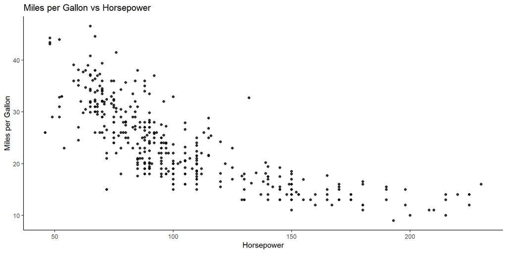

```r
library(ggplot2)
ggplot(Auto) +
  geom_point(aes(x = horsepower, y = mpg), alpha = 0.8) +
  ggtitle("Miles per Gallon vs Horsepower") +
  xlab("Horsepower") + ylab("Miles per Gallon") +
  theme_classic()
```

### Berdasarkan `origin`

```r
freq <- table(Auto$origin)
data.frame(cbind(freq, prop = prop.table(freq)))
```

| freq | prop |
| --- | --- |
| 245 | 0.6250000 |
| 68 | 0.1734694 |
| 79 | 0.2015306 |

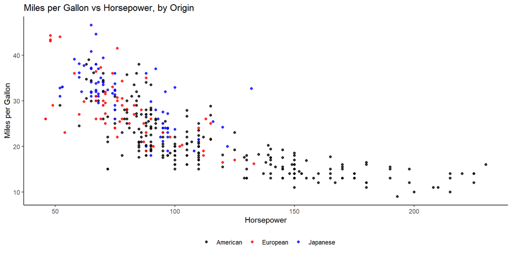

```r
p <- ggplot(Auto) +
  geom_point(aes(x = horsepower, y = mpg, color = as.factor(origin)), alpha = 0.8) +
  scale_color_manual(values = c("black", "red", "blue"),
                     labels = c("American", "European", "Japanese")) +
  ggtitle("Miles per Gallon vs Horsepower, by Origin") +
  xlab("Horsepower") + ylab("Miles per Gallon") +
  theme_classic() +
  theme(legend.title = element_blank(),
        legend.position = "bottom",
        legend.box = "horizontal")
p
```

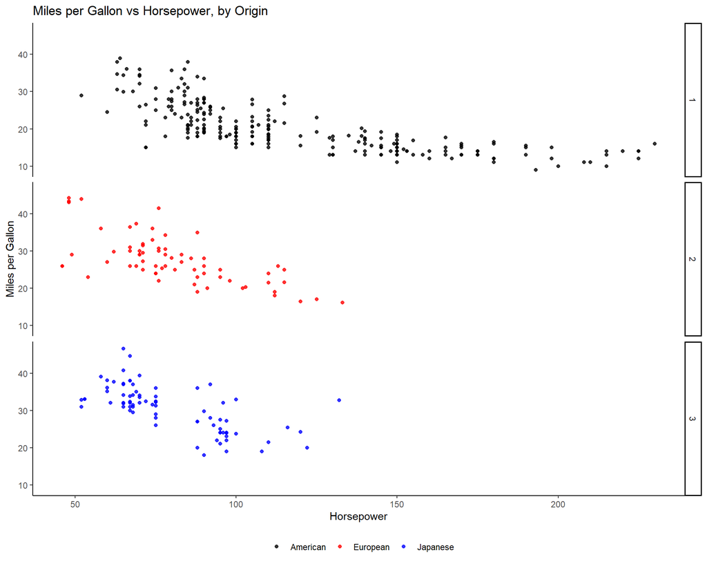

```r
p + facet_grid(origin ~ .)
```

Berdasarkan visualisasi di atas terlihat bahwa hubungan `mpg` dan `horsepower` tidak bersifat linear. Untuk itu diperlukan metode non-linear untuk mendapatkan pemodelan optimal.

## Semua Negara

```r
AutoKnots <- pctKnots(Auto$horsepower)

set.seed(1234)
orig0 <- generateAllREg(df = Auto,
                  orig = "Semua Negara",
                  degree = c(2:10), cut = c(2:10), knot = AutoKnots)
```

### *Cross validation*

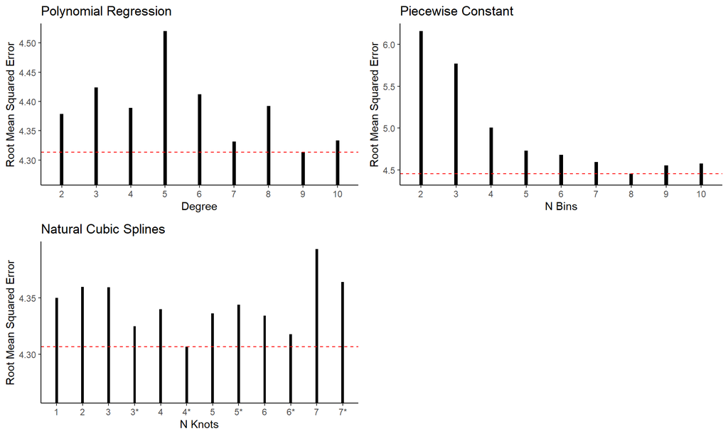

```r
orig0$pltCVGrid
```

### Ringkasan *tuning parameter* terbaik

```r
orig0$bestSummary
```

| origin | method | param | RMSE |
| --- | --- | --- | --- |
| Semua Negara | polynomial | 9 | 4.313204 |
| Semua Negara | piecewise | 8 | 4.453155 |
| Semua Negara | ncubicspline | 4* | 4.306619 |

```r
orig0$bestModel
```

|  | origin | method | param | RMSE |
| --- | --- | --- | --- | --- |
| 3 | Semua Negara | ncubicspline | 4* | 4.306619 |

*Tunning Parameter* **terbaik**

```r
orig0$bestParamDetail
```

```
##     5%    35%    65%    95%
##  60.55  85.00 105.00 180.00
```

### Nilai observasi *vs* prediksi

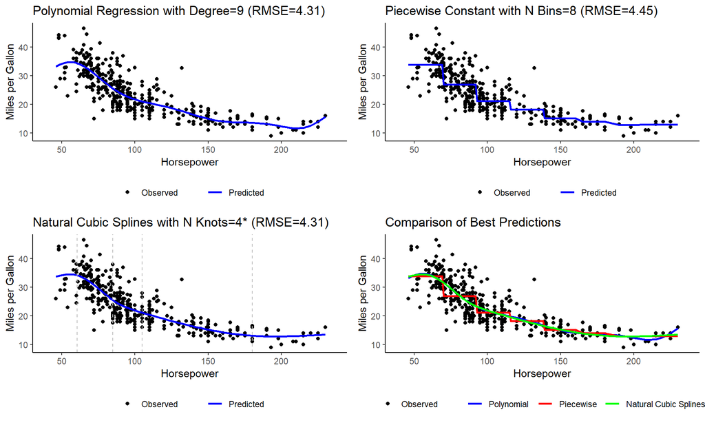

```r
orig0$pltPredGrid
```

Model terbaik yang diperoleh dari *cross-validation* adalah *natural cubic spline* dengan 4 knots.

### Ringkasan *modeling*

```r
summary(orig0$bestModelDetail)
```

```
##
## Call:
## NULL
##
## Deviance Residuals:
##      Min        1Q    Median        3Q       Max
## -15.7924   -2.6455   -0.2029    2.2116   15.4144
##
## Coefficients:
##                                                   Estimate Std. Error t value
## (Intercept)                                         33.789      1.570  21.516
## `ns(horsepower, knots = c(60.55, 85, 105, 180))1`   -9.327      1.597  -5.840
## `ns(horsepower, knots = c(60.55, 85, 105, 180))2`  -15.555      2.140  -7.268
## `ns(horsepower, knots = c(60.55, 85, 105, 180))3`  -22.579      1.904 -11.860
## `ns(horsepower, knots = c(60.55, 85, 105, 180))4`  -19.168      3.508  -5.465
## `ns(horsepower, knots = c(60.55, 85, 105, 180))5`  -21.579      1.798 -12.004
##                                                   Pr(>|t|)
## (Intercept)                                        < 2e-16 ***
## `ns(horsepower, knots = c(60.55, 85, 105, 180))1` 1.11e-08 ***
## `ns(horsepower, knots = c(60.55, 85, 105, 180))2` 2.04e-12 ***
## `ns(horsepower, knots = c(60.55, 85, 105, 180))3`  < 2e-16 ***
## `ns(horsepower, knots = c(60.55, 85, 105, 180))4` 8.33e-08 ***
## `ns(horsepower, knots = c(60.55, 85, 105, 180))5`  < 2e-16 ***
## ---
## Signif. codes:  0 '***' 0.001 '**' 0.01 '*' 0.05 '.' 0.1 ' ' 1
##
## (Dispersion parameter for gaussian family taken to be 18.44132)
##
##     Null deviance: 23819.0  on 391  degrees of freedom
## Residual deviance:  7118.4  on 386  degrees of freedom
## AIC: 2262.9
##
## Number of Fisher Scoring iterations: 2
```

## Origin 1: Amerika

```r
Auto1 <- Auto[Auto$origin == 1, ]
Auto1Knots <- pctKnots(Auto1$horsepower)

set.seed(1234)
orig1 <- generateAllREg(df = Auto1,
                  orig = "Amerika",
                  degree = c(2:10), cut = c(2:10), knot = Auto1Knots)
```

### *Cross validation*

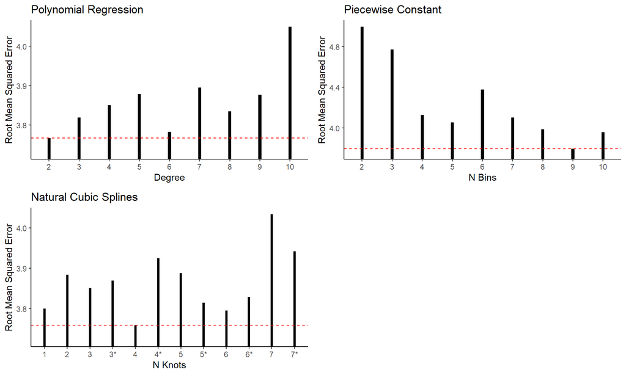

```r
orig1$pltCVGrid
```

### Ringkasan *tuning parameter* terbaik

```r
orig1$bestSummary
```

| origin | method | param | RMSE |
| --- | --- | --- | --- |
| Amerika | polynomial | 2 | 3.76728 |
| Amerika | piecewise | 9 | 3.794538 |
| Amerika | ncubicspline | 4 | 3.759049 |

```r
orig1$bestModel
```

|  | origin | method | param | RMSE |
| --- | --- | --- | --- | --- |
| 3 | Amerika | ncubicspline | 4 | 3.759049 |

*Tunning Parameter* **terbaik**

```r
orig1$bestParamDetail
```

```
##   20%   40%   60%   80%
##  85.0  99.2 122.0 150.0
```

### Nilai observasi *vs* prediksi

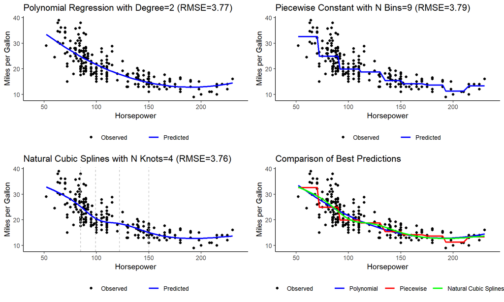

```r
orig1$pltPredGrid
```

### Ringkasan *modeling*

```r
summary(orig1$bestModelDetail)
```

```
##
## Call:
## NULL
##
## Deviance Residuals:
##      Min        1Q    Median        3Q       Max
## -13.8393   -2.3393   -0.2519    2.1876   12.8473
##
## Coefficients:
##                                                  Estimate Std. Error t value
## (Intercept)                                        32.869      2.003  16.409
## `ns(horsepower, knots = c(85, 99.2, 122, 150))1`  -14.266      1.904  -7.494
## `ns(horsepower, knots = c(85, 99.2, 122, 150))2`  -13.533      2.528  -5.352
## `ns(horsepower, knots = c(85, 99.2, 122, 150))3`  -19.748      1.689 -11.691
## `ns(horsepower, knots = c(85, 99.2, 122, 150))4`  -24.493      4.449  -5.505
## `ns(horsepower, knots = c(85, 99.2, 122, 150))5`  -16.706      1.655 -10.093
##                                                  Pr(>|t|)
## (Intercept)                                       < 2e-16 ***
## `ns(horsepower, knots = c(85, 99.2, 122, 150))1` 1.30e-12 ***
## `ns(horsepower, knots = c(85, 99.2, 122, 150))2` 2.04e-07 ***
## `ns(horsepower, knots = c(85, 99.2, 122, 150))3`  < 2e-16 ***
## `ns(horsepower, knots = c(85, 99.2, 122, 150))4` 9.51e-08 ***
## `ns(horsepower, knots = c(85, 99.2, 122, 150))5`  < 2e-16 ***
## ---
## Signif. codes:  0 '***' 0.001 '**' 0.01 '*' 0.05 '.' 0.1 ' ' 1
##
## (Dispersion parameter for gaussian family taken to be 14.29455)
##
##     Null deviance: 10120.8  on 244  degrees of freedom
## Residual deviance:  3416.4  on 239  degrees of freedom
## AIC: 1354.9
##
## Number of Fisher Scoring iterations: 2
```

## Origin 2: Eropa

```r
Auto2 <- Auto[Auto$origin == 2, ]
Auto2Knots <- pctKnots(Auto2$horsepower)

set.seed(1234)
orig2 <- generateAllREg(df = Auto2,
                  orig = "Eropa",
                  degree = c(2:8), cut = c(2:10), knot = Auto2Knots)
```

### *Cross validation*

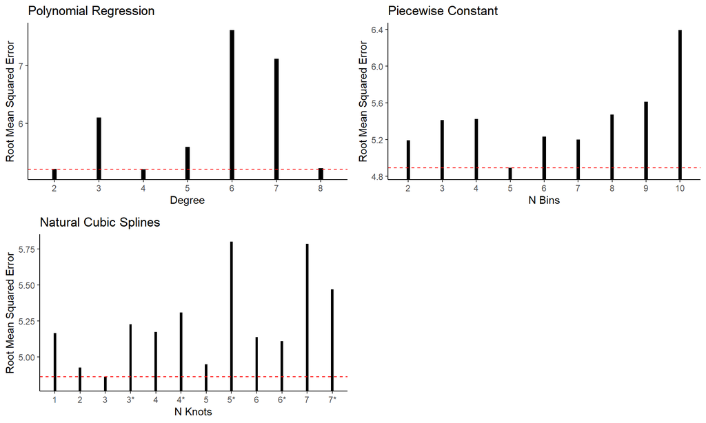

```r
orig2$pltCVGrid
```

### Ringkasan *tuning parameter* terbaik

```r
orig2$bestSummary
```

| origin | method | param | RMSE |
| --- | --- | --- | --- |
| Eropa | polynomial | 4 | 5.205988 |
| Eropa | piecewise | 5 | 4.891956 |
| Eropa | ncubicspline | 3 | 4.860623 |

```r
orig2$bestModel
```

|  | origin | method | param | RMSE |
| --- | --- | --- | --- | --- |
| 3 | Eropa | ncubicspline | 3 | 4.860623 |

*Tunning Parameter* **terbaik**

```r
orig2$bestParamDetail
```

```
##   25%   50%   75%
## 69.75 76.50 90.00
```

### Nilai observasi *vs* prediksi

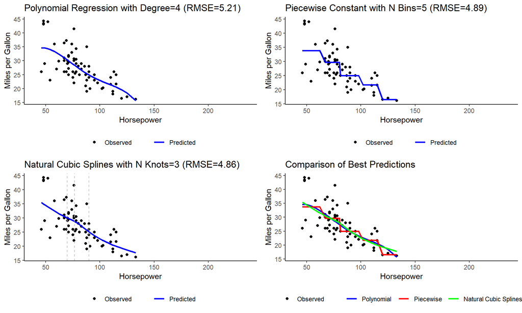

```r
orig2$pltPredGrid
```

### Ringkasan *modeling*

```r
summary(orig2$bestModelDetail)
```

```
##
## Call:
## NULL
##
## Deviance Residuals:
##      Min        1Q    Median        3Q       Max
## -10.4288   -2.7067   -0.6468    2.0588   12.6018
##
## Coefficients:
##                                               Estimate Std. Error t value
## (Intercept)                                     35.425      2.113  16.769
## `ns(horsepower, knots = c(69.75, 76.5, 90))1`   -6.851      2.532  -2.705
## `ns(horsepower, knots = c(69.75, 76.5, 90))2`  -12.103      3.160  -3.830
## `ns(horsepower, knots = c(69.75, 76.5, 90))3`  -20.101      5.503  -3.652
## `ns(horsepower, knots = c(69.75, 76.5, 90))4`  -15.407      3.897  -3.954
##                                               Pr(>|t|)
## (Intercept)                                    < 2e-16 ***
## `ns(horsepower, knots = c(69.75, 76.5, 90))1` 0.008763 **
## `ns(horsepower, knots = c(69.75, 76.5, 90))2` 0.000298 ***
## `ns(horsepower, knots = c(69.75, 76.5, 90))3` 0.000530 ***
## `ns(horsepower, knots = c(69.75, 76.5, 90))4` 0.000197 ***
## ---
## Signif. codes:  0 '***' 0.001 '**' 0.01 '*' 0.05 '.' 0.1 ' ' 1
##
## (Dispersion parameter for gaussian family taken to be 24.63829)
##
##     Null deviance: 2901.0  on 67  degrees of freedom
## Residual deviance: 1552.2  on 63  degrees of freedom
## AIC: 417.67
##
## Number of Fisher Scoring iterations: 2
```

## Origin 3: Jepang

```r
Auto3 <- Auto[Auto$origin == 3, ]
Auto3Knots <- pctKnots(Auto3$horsepower)

set.seed(1234)
orig3 <- generateAllREg(df = Auto3,
                  orig = "Jepang",
                  degree = c(2:8), cut = c(2:10), knot = Auto3Knots)
```

### *Cross validation*

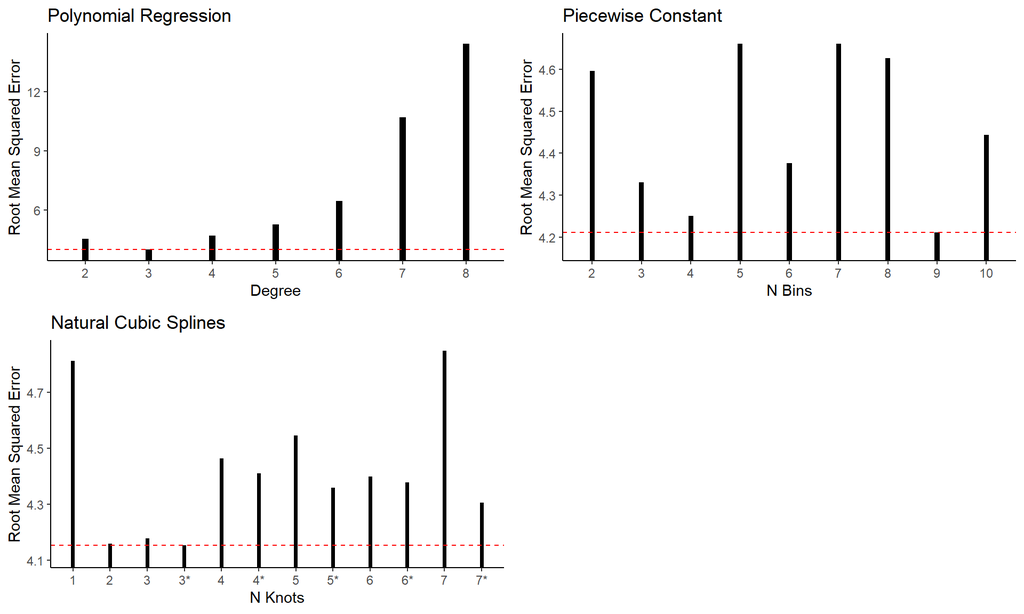

```r
orig3$pltCVGrid
```

### Ringkasan *tuning parameter* terbaik

```r
orig3$bestSummary
```

| origin | method | param | RMSE |
| --- | --- | --- | --- |
| Jepang | polynomial | 3 | 4.013379 |
| Jepang | piecewise | 9 | 4.211734 |
| Jepang | ncubicspline | 3* | 4.152535 |

```r
orig3$bestModel
```

| origin | method | param | RMSE |
| --- | --- | --- | --- |
| Jepang | polynomial | 3 | 4.013379 |

### Nilai observasi *vs* prediksi

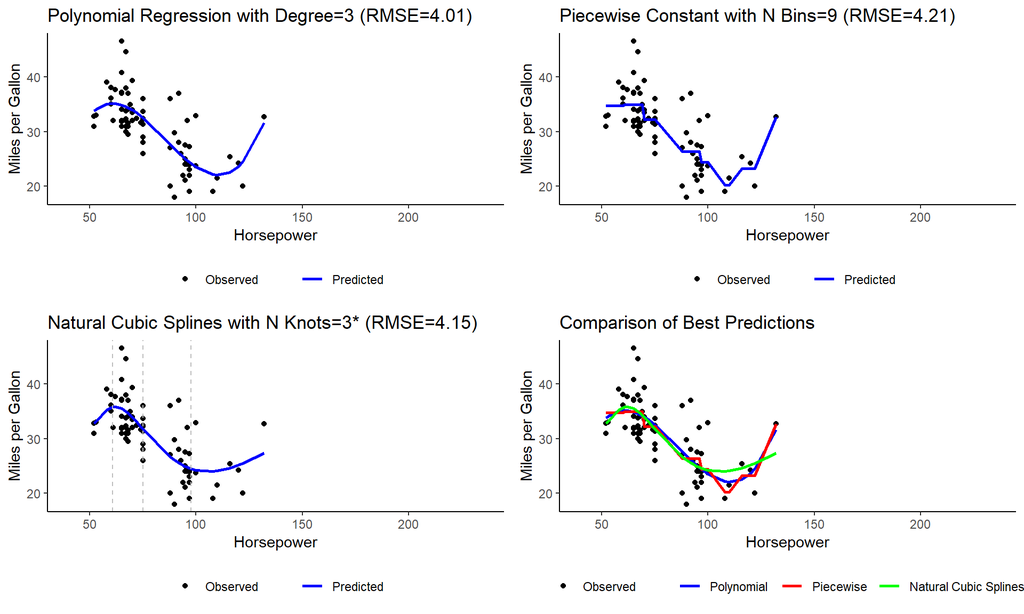

```r
orig3$pltPredGrid
```

### Ringkasan *modeling*

```r
summary(orig3$bestModelDetail)
```

```
##
## Call:
## NULL
##
## Deviance Residuals:
##     Min       1Q   Median       3Q      Max
## -8.8602  -2.7115  -0.5224   2.1985  11.6985
##
## Coefficients:
##                                 Estimate Std. Error t value Pr(>|t|)
## (Intercept)                      30.4506     0.4536  67.138  < 2e-16 ***
## `poly(horsepower, degree = 3)1` -36.2030     4.0312  -8.981 1.62e-13 ***
## `poly(horsepower, degree = 3)2`   9.1966     4.0312   2.281   0.0254 *
## `poly(horsepower, degree = 3)3`  16.6991     4.0312   4.142 8.92e-05 ***
## ---
## Signif. codes:  0 '***' 0.001 '**' 0.01 '*' 0.05 '.' 0.1 ' ' 1
##
## (Dispersion parameter for gaussian family taken to be 16.25097)
##
##     Null deviance: 2892.9  on 78  degrees of freedom
## Residual deviance: 1218.8  on 75  degrees of freedom
## AIC: 450.35
##
## Number of Fisher Scoring iterations: 2
```

## Origin 3: Jepang *(Refined)*

Meskipun mempunyai RMSE yang paling rendah berdasarkan hasil *k-fold cross validation*, model terbaik secara visual menunjukkan adanya belokan di sekitar ujung-ujung kurva. Hal ini dirasa kurang masuk akal. Untuk itu perlu dilakukan “revisi” model. Karena ketiga metode menunjukkan pola yang sama, akan dilakukan revisi terhadap model *natural cubic spline*. Langkah yang dilakukan adalah dengan menghapus knot dan mengubah lokasi (dalam hal ini adalah persentil 10 sampai dengan 90).

```r
newKnots <- as.list(quantile(Auto3$horsepower, seq(0.1, 0.9, by=0.1)))
names(newKnots) <- paste0("1.", letters[1:length(newKnots)])

set.seed(1234)
orig3b <- generateAllREg(df = Auto3,
                  orig = "Jepang",
                  degree = c(2:8), cut = c(2:10), knot = newKnots, best = 3)
```

### *Cross validation*

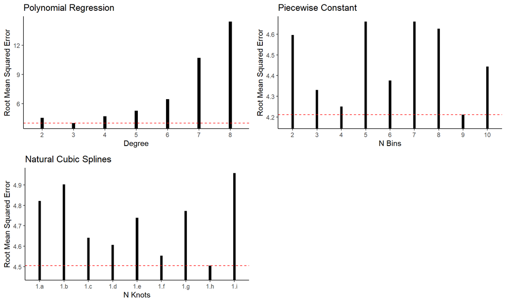

```r
orig3b$pltCVGrid
```

### Ringkasan *tuning parameter* terbaik

```r
orig3b$bestSummary
```

| origin | method | param | RMSE |
| --- | --- | --- | --- |
| Jepang | polynomial | 3 | 4.013379 |
| Jepang | piecewise | 9 | 4.211734 |
| Jepang | ncubicspline | 1.h | 4.504423 |

```r
orig3b$bestModel
```

|  | origin | method | param | RMSE |
| --- | --- | --- | --- | --- |
| 3 | Jepang | ncubicspline | 1.h | 4.504423 |

### Ringkasan *modeling*

```r
summary(orig3b$bestModelDetail)
```

```
##
## Call:
## NULL
##
## Deviance Residuals:
##     Min       1Q   Median       3Q      Max
## -8.9311  -2.5978  -0.3679   2.1341  12.3869
##
## Coefficients:
##                               Estimate Std. Error t value Pr(>|t|)
## (Intercept)                     38.918      1.250  31.146  < 2e-16 ***
## `ns(horsepower, knots = 96)1`  -25.236      2.968  -8.504 1.19e-12 ***
## `ns(horsepower, knots = 96)2`   -7.348      3.164  -2.322   0.0229 *
## ---
## Signif. codes:  0 '***' 0.001 '**' 0.01 '*' 0.05 '.' 0.1 ' ' 1
##
## (Dispersion parameter for gaussian family taken to be 19.30245)
##
##     Null deviance: 2892.9  on 78  degrees of freedom
## Residual deviance: 1467.0  on 76  degrees of freedom
## AIC: 462.99
##
## Number of Fisher Scoring iterations: 2
```

### Perbandingan model lama dan baru

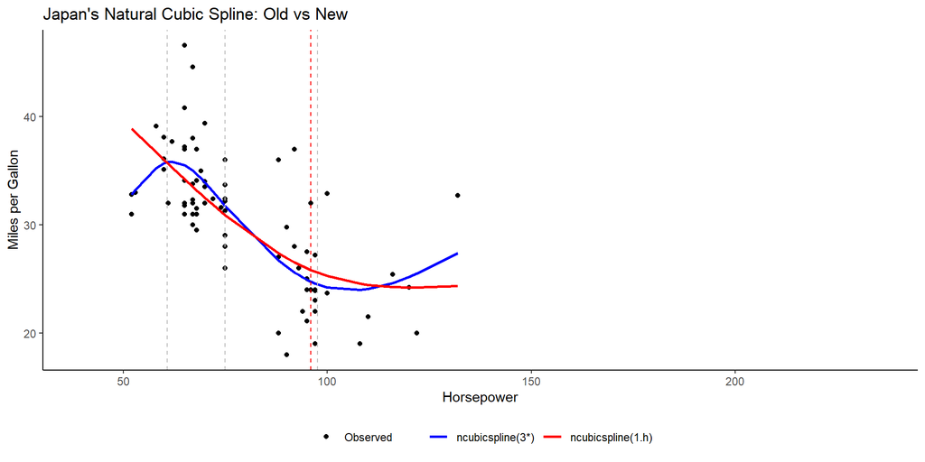

```r
plt <- orig3$pltPred[[3]]


plt + geom_line(data = orig3b$model[[3]]$predValue,
                aes(x = horsepower, y = pred, color = "1"), size = 1) +
scale_color_manual(labels = c(sprintf("%s(%s)",orig3$bestSummary[3,2],orig3$bestSummary[3,3]),
                              sprintf("%s(%s)",orig3b$bestModel[1,2],orig3b$bestModel[1,3])), values = c("blue", "red")) +
geom_vline(xintercept = orig3b$bestParamDetail, linetype="dashed", color = "red") +
ggtitle("Japan's Natural Cubic Spline: Old vs New")
```

Curva menunjukkan bahwa belokan bisa diminimalisasi. Konsekuensinya, RMSE meningkat dari 4.15 menjadi 4.50.

### Nilai observasi *vs* prediksi

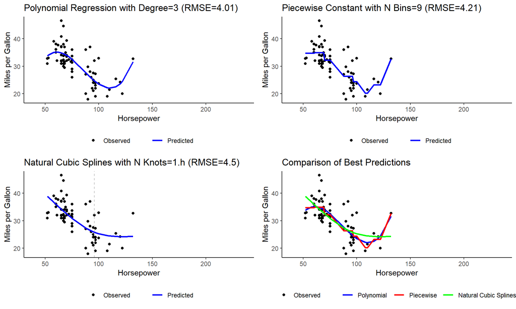

```r
orig3b$pltPredGrid
```

## All Models

Dengan demikin diperoleh pemodelan optimal untuk masing-masing negara asal sebagai berikut:

```r
finalModels <- rbind(orig1$bestModel, orig2$bestModel, orig3b$bestModel)
finalModels
```

|  | origin | method | param | RMSE |
| --- | --- | --- | --- | --- |
| 3 | Amerika | ncubicspline | 4 | 3.759049 |
| 31 | Eropa | ncubicspline | 3 | 4.860623 |
| 32 | Jepang | ncubicspline | 1.h | 4.504423 |

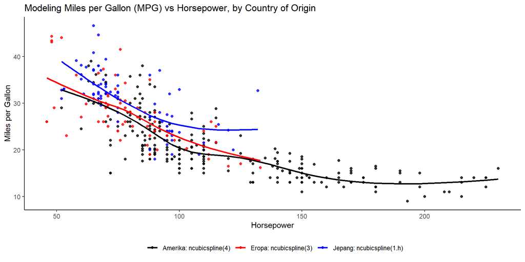

```r
finalPred <- rbind(orig1$predBestFinal, orig2$predBestFinal, orig3b$predBestFinal)

finalPred <- merge(finalPred, finalModels)
finalPred$originModel <- sprintf('%s: %s(%s)', finalPred$origin, finalPred$method, finalPred$param)


ggplot(finalPred) +
  geom_point(aes(x = horsepower, y = mpg, color = originModel), alpha = 0.8) +
  geom_line(aes(x = horsepower, y = pred, color = originModel), size = 1) +
  scale_color_manual(values = c("black", "red", "blue"))  +
  theme_classic() +
  ggtitle("Modeling Miles per Gallon (MPG) vs Horsepower, by Country of Origin") +
  xlab("Horsepower") + ylab("Miles per Gallon") +
  theme(legend.title = element_blank(),
        legend.position = "bottom",
        legend.box = "horizontal")
```

# Kesimpulan

- Perlu kehati-hatian dalam memilih *tuning parameter*.
- Pemodelan terbaik hasil dari *cross validation*, belum tentu merupakan model yang bisa diterima, sehingga perlu pandangan analis untuk melakukan evaluasi terhadap model-model yang diperoleh.
- Model non-linier mampu digunakan untuk melakukan prediksi efisiensi bahan bakar menggunakan *horsepower*.
- Secara umum, semakin tinggi *horsepower*, maka kendaraan semakin boros dalam penggunaan bahan bakar (*mpg* lebih rendah). Hal ini berlaku untuk ketiga negara asal.
- Berdasarkan plot terakhir, terlihat bahwa untuk `horsepower` yang sama, kendaraan yang berasal dari Jepang lebih hemat dalam penggunaan bahan bakar, diikuti oleh Eropa dan Amerika.

# Daftar Pustaka

Dito, Gerry A. (2021), *Regresi Polinomial, Regresi Fungsi Tangga dan Regresi Spline di R*, https://gerrydito.github.io/Regresi-Polinomial,-Regresi-Fungsi-Tangga-dan-Regresi-Spline/ (Oct 29, 2021).

Harrell, Frank E., Jr. (2015). *Regression Modeling Strategies. Springer Series in Statistics*, Springer.

James, G.; Witten, D.; Hastie, T. & Tibshirani, R. (2013), *An Introduction to Statistical Learning: with Applications in R*, Springer.

[^1]: Mahasiswa Pascasarjana Statistika dan Sains Data, Institut Pertanian Bogor, NIM: G1501211061, nur.andi@apps.ipb.ac.id